[figure not shown]

# Keras

**Design Goals:**

- User friendliness
- Modularity
- Easy extensibility
- Work with Python

# MNIST

The MNIST database (Modified National Institute of Standards and Technology database) is a **dataset**

- 28x28 images showing handwritten digits
- 55K training, 5K validation and 10K test samples
- multi-class classification task

```python
import tensorflow as tf
from tensorflow.examples.tutorials.mnist import input_data
mnist = input_data.read_data_sets("MNIST_data/")
```

```
Extracting MNIST_data/train-images-idx3-ubyte.gz
Extracting MNIST_data/train-labels-idx1-ubyte.gz
Extracting MNIST_data/t10k-images-idx3-ubyte.gz
Extracting MNIST_data/t10k-labels-idx1-ubyte.gz
```

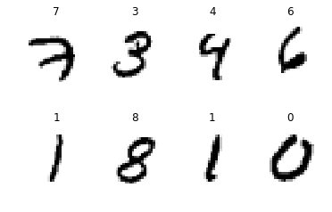

```python
%matplotlib inline
import matplotlib.pyplot as plt
fig, axes = plt.subplots(2, 4)
for i, ax in enumerate(axes.flat):
    ax.set_title(mnist.train.labels[i])
    ax.imshow(mnist.train.images[i].reshape(28,28), cmap=plt.cm.Greys)
    ax.axis('off')
```

## tf.keras

Tensorflow officially supports the **keras** API

### Model

```python
model = tf.keras.Sequential()
model.add(tf.keras.layers.Reshape((28, 28, 1), input_shape=[28*28]))
model.add(tf.keras.layers.Conv2D(32, kernel_size=(5, 5), strides=(1,1),
                                 padding="same", activation='relu'))
model.add(tf.keras.layers.MaxPooling2D(pool_size=(2, 2), strides=(2,2)))
model.add(tf.keras.layers.Flatten())
model.add(tf.keras.layers.Dense(10, activation='softmax'))
```

```python
model.summary()
```

```
_________________________________________________________________
Layer (type)                 Output Shape              Param #
=================================================================
reshape_1 (Reshape)          (None, 28, 28, 1)         0
_________________________________________________________________
conv2d_1 (Conv2D)            (None, 28, 28, 32)        832
_________________________________________________________________
max_pooling2d_1 (MaxPooling2 (None, 14, 14, 32)        0
_________________________________________________________________
flatten_1 (Flatten)          (None, 6272)              0
_________________________________________________________________
dense_1 (Dense)              (None, 10)                62730
=================================================================
Total params: 63,562
Trainable params: 63,562
Non-trainable params: 0
_________________________________________________________________
```

### Compile

```python
model.compile(loss=tf.keras.losses.categorical_crossentropy,
              optimizer=tf.keras.optimizers.SGD(lr=0.5),
              metrics=['accuracy'])
```

[output not shown]

### Fitting

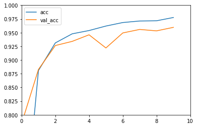

```
<tensorflow.python.keras._impl.keras.callbacks.History at 0x7f5b5be59978>
```

```python
nevents = 5000
model.fit(mnist.train.images[:nevents],
          tf.keras.utils.to_categorical(mnist.train.labels[:nevents], 10),
          batch_size=256, epochs=10, callbacks=[PlotLosses(10)], verbose=0,
          validation_data=(mnist.validation.images,
                           tf.keras.utils.to_categorical(mnist.validation.labels, 10)))
```

### Evaluation

```python
model.evaluate(mnist.test.images, tf.keras.utils.to_categorical(mnist.test.labels, 10), verbose=0)
```

```
[0.1268268010802567, 0.9606]
```

### Prediction

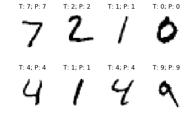

```python
prediction = model.predict(mnist.test.images[:8])

fig, axes = plt.subplots(2, 4)
for i, ax in enumerate(axes.flat):
    ax.set_title("T: {}; P: {}".format(mnist.test.labels[i], prediction[i].argmax()))
    ax.imshow(mnist.test.images[i].reshape(28,28), cmap=plt.cm.Greys)
    ax.axis('off')
```

### Exercise

Add regularization to the network by adding

```
 kernel_regularizer=tf.keras.regularizers.l2(0.001),
```

as a parameter to the individual layers.

### Exercise

Increase the depth of the above model by adding more convolution and pooling layers.  
How deep can you go before the training gets unstable.?

# Gaining Depth

In the lecture we discussed the **Vanishing Gradient Problem** and some techniques so avoid it.

- **ReLU activation**
- **he initialization**
- **batch normalization**

```python
model = tf.keras.Sequential()
model.add(tf.keras.layers.Reshape((28, 28, 1), input_shape=[28*28]))

for i in range(1, 4):
    model.add(tf.keras.layers.Conv2D(16*i, kernel_size=(3, 3), strides=(1,1),
                                     kernel_initializer=tf.keras.initializers.he_normal(),
                                     padding="same", use_bias=False))
    model.add(tf.keras.layers.BatchNormalization())
    model.add(tf.keras.layers.Activation('relu'))

model.add(tf.keras.layers.GlobalAveragePooling2D())
model.add(tf.keras.layers.Dense(64, kernel_initializer=tf.keras.initializers.he_normal()))
model.add(tf.keras.layers.BatchNormalization())
model.add(tf.keras.layers.Activation('relu'))
model.add(tf.keras.layers.Dense(10, kernel_initializer=tf.keras.initializers.he_normal(),
                                activation='softmax'))
print(model.summary())
```

```
_________________________________________________________________
Layer (type)                 Output Shape              Param #
=================================================================
reshape_2 (Reshape)          (None, 28, 28, 1)         0
_________________________________________________________________
conv2d_2 (Conv2D)            (None, 28, 28, 16)        144
_________________________________________________________________
batch_normalization_1 (Batch (None, 28, 28, 16)        64
_________________________________________________________________
activation_1 (Activation)    (None, 28, 28, 16)        0
_________________________________________________________________
conv2d_3 (Conv2D)            (None, 28, 28, 32)        4608
_________________________________________________________________
batch_normalization_2 (Batch (None, 28, 28, 32)        128
_________________________________________________________________
activation_2 (Activation)    (None, 28, 28, 32)        0
_________________________________________________________________
conv2d_4 (Conv2D)            (None, 28, 28, 48)        13824
_________________________________________________________________
batch_normalization_3 (Batch (None, 28, 28, 48)        192
_________________________________________________________________
activation_3 (Activation)    (None, 28, 28, 48)        0
_________________________________________________________________
global_average_pooling2d_1 ( (None, 48)                0
_________________________________________________________________
dense_2 (Dense)              (None, 64)                3136
_________________________________________________________________
batch_normalization_4 (Batch (None, 64)                256
_________________________________________________________________
activation_4 (Activation)    (None, 64)                0
_________________________________________________________________
dense_3 (Dense)              (None, 10)                650
=================================================================
Total params: 23,002
Trainable params: 22,682
Non-trainable params: 320
_________________________________________________________________
None
```

### Callbacks

Callbacks are used in keras to perform specific actions after every batch or after each epoch. Previously we used a callback to update our accuracy plot during the training, now we add two more callbacks:

- `tf.keras.callbacks.EarlyStopping` will automatically stop the training if the accuracy on the validation sample does no longer increase
- `tf.keras.callbacks.ModelCheckpoint` will save the best model automatically

The **early stopping** provides a cheap and easy way to regularize our model.

```python
callbacks = [tf.keras.callbacks.EarlyStopping(monitor='val_acc', patience=10, mode='max', verbose=1),
             tf.keras.callbacks.ModelCheckpoint('checkpoints', monitor='val_acc', save_best_only=True, mode='max', verbose=1),
             PlotLosses(10)]
```

### Fitting

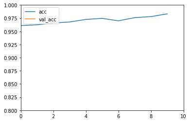

[output not shown]

```python
model.fit(mnist.train.images[:nevents],
          tf.keras.utils.to_categorical(mnist.train.labels[:nevents], 10),
          batch_size=256, epochs=10, callbacks=callbacks, verbose=0,
          validation_data=(mnist.validation.images,
                           tf.keras.utils.to_categorical(mnist.validation.labels, 10)))
```

### Evaluation

```python
model.evaluate(mnist.test.images, tf.keras.utils.to_categorical(mnist.test.labels, 10), verbose=0)
```

```
[0.7459862817764282, 0.727]
```

### Exercise

Modify the above model and observe how the number of parameters change.

- How many parameters are associated with a convolutional layer (as a function of kernel size, stride, and feature maps)
- How many parameters are associated with a dense layer (as a function of input and output layers)
- How many parameters are associated with the batch normalization layer
- How many parameters are associated with the pooling layer

### Exercise

Use a different optimizer to train the model. For instance

```
 optimizer=tf.keras.optimizers.Adam(),
```

# Recurrent Neural Network

## Text-Corpus

```python
import wikipedia
import unicodedata
text = wikipedia.page('France').content
text = unicodedata.normalize('NFKD', text).encode('ascii','ignore')
len(text), text[:100]
```

```
(128089,
 b'France (French: [fs]), officially the French Republic (French: Republique francaise [epyblik fsz]), ')
```

### One-Hot Encoding

```python
import numpy as np
def one_hot_encoding(binary_text):
    mapping = np.fromiter(binary_text, dtype=np.int8)
    return tf.keras.utils.to_categorical(mapping, 128)

one_hot_encoded_text = one_hot_encoding(text)
```

### Training Dataset

```python
nevents = 30000
train_x = []
train_y = []
for i in range(30, len(one_hot_encoded_text)-31):
    train_x.append(one_hot_encoded_text[i:i+30])
    train_y.append(one_hot_encoded_text[i+31])
train_x = np.array(train_x[:nevents])
train_y = np.array(train_y[:nevents])
```

### LSTM Model

```python
model = tf.keras.Sequential()
model.add(tf.keras.layers.LSTM(128, input_shape=(30, 128)))
model.add(tf.keras.layers.Dense(128, activation='softmax'))
print(model.summary())
```

```
WARNING:tensorflow:From /home/thomas/venv/lib/python3.5/site-packages/tensorflow/python/keras/_impl/keras/backend.py:1456: calling reduce_sum (from tensorflow.python.ops.math_ops) with keep_dims is deprecated and will be removed in a future version.
Instructions for updating:
keep_dims is deprecated, use keepdims instead
_________________________________________________________________
Layer (type)                 Output Shape              Param #
=================================================================
lstm_1 (LSTM)                (None, 128)               131584
_________________________________________________________________
dense_1 (Dense)              (None, 128)               16512
=================================================================
Total params: 148,096
Trainable params: 148,096
Non-trainable params: 0
_________________________________________________________________
None
```

### Compilation

```python
model.compile(loss=tf.keras.losses.categorical_crossentropy,
              optimizer=tf.keras.optimizers.RMSprop(lr=0.01),
              metrics=['accuracy'])
```

[output not shown]

### Text Generation Callback

```python
import sys
class TextGeneration(tf.keras.callbacks.Callback):
    def __init__(self, temperature=1.0):
        self.temperature = temperature
        self.choices = list(range(128))

    def on_epoch_end(self, epoch, logs={}):
        sentence = b'a country whose territory consists'[:30]
        print()
        sys.stdout.write(sentence)
        for i in range(200):
            preds = model.predict(np.array([one_hot_encoding(sentence)]), verbose=0)[0]
            a = np.log(preds) / self.temperature
            dist = np.exp(a)/np.sum(np.exp(a))
            next_char = bytes([np.random.choice(self.choices, p=dist)])
            sentence = sentence[1:] + next_char
            sys.stdout.write(next_char)
        sys.stdout.flush()
        print()
```

### Fitting

```python
model.fit(train_x, train_y, batch_size=256, epochs=10, callbacks=[TextGeneration()], verbose=1)
```

```
a country whose territory consiue nter rien aoot hmeu rpierwsfin nmegorgaeu eand hmtoaoshr eeyat hsaha foc 1vrs sa itani Fars r135,0,wl eih nbt o tytgseinaid o hraae.Aetrur,clnae.I o hsohdCte nrak.A rvmig o erwoe naz,igdrena nrhss

a country whose territory consiassom o 7'.nI lfdrtdcepid stddee,wrhtin dcnttry etadee  o hrloe fueesios i t femalase edetanesos adt hltre teeietnualc mmeriul foe epliy nesbtocudy e adiheCuhl ernis fudFan t rscile ra nedrbria d eli

a country whose territory consit foren lte 6etansd hsae fomtacam ryahs t h edtrcvdbintr.ittalin ryuseai,a nmabeslruinu adailnuie nae poel oemnveoie,dsaen,ttr it1uctd n nmeniu yrscoin ntal.Atiae' rvcin adsoiaid.
n etlgo,ostadih 40.

a country whose territory consitnu,wetoie cuhrs  uoin =

h ae hreivd frmniswug eihtenugstsnpnkosansah eprvdiin prvnio oy2a o atousy o2196 sa as nmigenRmnrsie fubec aseneytapmntoal nmiles efrpidtpososcos frmairu s rsg,toe dmededyos

a country whose territory consiue adenohe h trces nteslvry zn.Tebilgns nmeg rsamno feeriisduastrc) Wasws u yagin nredbr o 3i.Aws.I'anes fosih fomtac.I na o mldeeme,edt d ataosial usuhral,
Fakigcat uatd.Ftt o Furig nmrnusftrvytin f

a country whose territory consic.wid Guedd ebutey ntil ntluie nae ucenre nmegenaiid o 288 nth asevle h fieios nrakistt foloi nwhre ocuisc npliv oios iatrcetie. o aripia cis rcmnin ntAyassas srutoo fo 7g1 4 9 mlg nee atl ameie nwtn

a country whose territory consctnai sldvy i o.Alet Do asas) yasblnki.Mrt nmegos yayi o prmsnftny Jl,snet-oe rplii osio oe hsces fodddrsweyanttnr hl nlhiee ndhs epethcil,atrnpn3s ntrhsie frmdais nmlie hetramstlsfenali-osoc nais rcu

a country whose territory consatothanefedae h eritoyod Fesc itinrC(E eproimnFarpiaiae raeentnel h are.lbtinewar uinettrtias ateCuitdu naeo,mgih,ashrayar rnale rfabintdcnios eale italryhpotdsah nruieeraeatd,atryas etet hmtoin Cahii

a country whose territory consctrs fo lse h ntoblcuin adsors aderuia frpcciai goeoe soe eioetl Oraceia caryas hmcerete yan xpavlos hsceriy yar,ay hruhoden rtee nmere frmc,soe ) hgeknm n lgds cnrus nmesalycb o aruteie,bi lu
hdy eta

a country whose territory consihssos frmsisins frm oe,asias  rmadca poe o Cah eoad rmenlp.Mihcrali,aie prvst nwih ntepos urye 4l
```

```
dwrl efutos sou i 1 intwrn fud ntig ntay yay.Bt s npeaiafa fo oe atrcmltts eylciilu c  clrii ncadsttnu
```

```
<tensorflow.python.keras._impl.keras.callbacks.History at 0x7f90d6053278>
```